# Special Modeling Topics

Brandon LeBeau

March 6, 2017

I want to spend a little bit of time talking about ways to model non-linear trends within a linear model as well as show an example of conducting a logistic regression within R using the `glm` function. This set of notes will use the following packages:

```r
library(modelr)
library(broom)
library(forcats)
library(tidyverse)
```

## Modeling non-linear trends

Modeling non-linear trends can be important and a great way to increase variance explained. There are many ways to model non-linear trends, including non-linear models, but I am going to focus on a linear modeling framework to include non-linear trends by adding quadratic terms.

These types of models are flexible and relatively easy to interpret, however have the drawback that prediction outside of the data at hand (extrapolation) can be problematic. Using the final model from the model assumptions lecture, lets see if we can improve model fit and the trend in the residuals by adding some non-linearity in the form of quadratic terms.

If you recall, here is the model that was used last time.

```r
heights2 <- heights %>%
  mutate(
    marital_comb = fct_recode(marital,
                              'Other' = 'separated',
                              'Other' = 'widowed'
    ),
    income2 = ifelse(income == 0, .001, income),
    height2 = height - mean(height, na.rm = TRUE),
    education2 = education - mean(education, na.rm = TRUE),
    weight2 = weight - mean(weight, na.rm = TRUE),
    log_income = log(income2)
  )
afqt_alt <- lm(afqt ~ marital_comb + height2 + education2 +
                 log_income + weight2, data = heights2)
summary(afqt_alt)
```

```
Call:
lm(formula = afqt ~ marital_comb + height2 + education2 + log_income +
    weight2, data = heights2)

Residuals:
    Min      1Q  Median      3Q     Max
-80.466 -16.515  -2.036  16.088 101.730

Coefficients:
                      Estimate Std. Error t value Pr(>|t|)
(Intercept)          32.645765   0.717463  45.502  < 2e-16 ***
marital_combmarried   9.312248   0.802952  11.598  < 2e-16 ***
marital_combOther    -2.537031   1.231340  -2.060   0.0394 *
marital_combdivorced  4.790976   0.913836   5.243 1.63e-07 ***
height2               0.781474   0.077526  10.080  < 2e-16 ***
education2            5.911616   0.111848  52.854  < 2e-16 ***
log_income            0.395176   0.038720  10.206  < 2e-16 ***
weight2              -0.027669   0.007074  -3.911 9.27e-05 ***
---
Signif. codes:  0 â€˜***â€™ 0.001 â€˜**â€™ 0.01 â€˜*â€™ 0.05 â€˜.â€™ 0.1 â€˜ â€™ 1

Residual standard error: 22.57 on 6637 degrees of freedom
  (361 observations deleted due to missingness)
Multiple R-squared:  0.3969,    Adjusted R-squared:  0.3963
F-statistic:   624 on 7 and 6637 DF,  p-value: < 2.2e-16
```

Let’s see if there are non-linear trends in the height, weight, or income variables. I am going to add these by specifically creating additional variables and using these as new predictors. You could also create these by using the insulate function `I()` to do the operation within the model syntax.

```r
heights2 <- heights2 %>%
  mutate(
    height2_quad = height2 ^ 2,
    weight2_quad = weight2 ^ 2,
    log_income_quad = log_income ^ 2,
    education2_quad = education2 ^ 2
  )
afqt_alt <- lm(afqt ~ marital_comb + height2 + education2 +
                 log_income + weight2 + education2_quad +
                 height2_quad + weight2_quad + log_income_quad,
               data = heights2)
summary(afqt_alt)
```

```
Call:
lm(formula = afqt ~ marital_comb + height2 + education2 + log_income +
    weight2 + education2_quad + height2_quad + weight2_quad +
    log_income_quad, data = heights2)

Residuals:
    Min      1Q  Median      3Q     Max
-77.098 -16.265  -2.331  15.587  91.339

Coefficients:
                       Estimate Std. Error t value Pr(>|t|)
(Intercept)           1.665e+01  1.598e+00  10.419  < 2e-16 ***
marital_combmarried   8.340e+00  7.993e-01  10.434  < 2e-16 ***
marital_combOther    -2.604e+00  1.218e+00  -2.137   0.0326 *
marital_combdivorced  4.262e+00  9.061e-01   4.703 2.61e-06 ***
height2               7.488e-01  7.967e-02   9.399  < 2e-16 ***
education2            5.467e+00  1.173e-01  46.609  < 2e-16 ***
log_income           -3.828e-01  8.307e-02  -4.609 4.12e-06 ***
weight2              -4.652e-02  8.046e-03  -5.782 7.72e-09 ***
education2_quad       5.535e-02  2.488e-02   2.224   0.0262 *
height2_quad         -3.018e-02  1.392e-02  -2.169   0.0302 *
weight2_quad          4.135e-04  8.359e-05   4.947 7.73e-07 ***
log_income_quad       2.177e-01  2.018e-02  10.791  < 2e-16 ***
---
Signif. codes:  0 â€˜***â€™ 0.001 â€˜**â€™ 0.01 â€˜*â€™ 0.05 â€˜.â€™ 0.1 â€˜ â€™ 1

Residual standard error: 22.33 on 6633 degrees of freedom
  (361 observations deleted due to missingness)
Multiple R-squared:  0.4102,    Adjusted R-squared:  0.4092
F-statistic: 419.3 on 11 and 6633 DF,  p-value: < 2.2e-16
```

Alternatively, this model could look like:

```r
afqt_alt <- lm(afqt ~ marital_comb + height2 + education2 +
                 log_income + weight2 + I(education2^2) +
                 I(height2^2) + I(weight2^2) + I(log_income^2),
               data = heights2)
summary(afqt_alt)
```

```
Call:
lm(formula = afqt ~ marital_comb + height2 + education2 + log_income +
    weight2 + I(education2^2) + I(height2^2) + I(weight2^2) +
    I(log_income^2), data = heights2)

Residuals:
    Min      1Q  Median      3Q     Max
-77.098 -16.265  -2.331  15.587  91.339

Coefficients:
                       Estimate Std. Error t value Pr(>|t|)
(Intercept)           1.665e+01  1.598e+00  10.419  < 2e-16 ***
marital_combmarried   8.340e+00  7.993e-01  10.434  < 2e-16 ***
marital_combOther    -2.604e+00  1.218e+00  -2.137   0.0326 *
marital_combdivorced  4.262e+00  9.061e-01   4.703 2.61e-06 ***
height2               7.488e-01  7.967e-02   9.399  < 2e-16 ***
education2            5.467e+00  1.173e-01  46.609  < 2e-16 ***
log_income           -3.828e-01  8.307e-02  -4.609 4.12e-06 ***
weight2              -4.652e-02  8.046e-03  -5.782 7.72e-09 ***
I(education2^2)       5.535e-02  2.488e-02   2.224   0.0262 *
I(height2^2)         -3.018e-02  1.392e-02  -2.169   0.0302 *
I(weight2^2)          4.135e-04  8.359e-05   4.947 7.73e-07 ***
I(log_income^2)       2.177e-01  2.018e-02  10.791  < 2e-16 ***
---
Signif. codes:  0 â€˜***â€™ 0.001 â€˜**â€™ 0.01 â€˜*â€™ 0.05 â€˜.â€™ 0.1 â€˜ â€™ 1

Residual standard error: 22.33 on 6633 degrees of freedom
  (361 observations deleted due to missingness)
Multiple R-squared:  0.4102,    Adjusted R-squared:  0.4092
F-statistic: 419.3 on 11 and 6633 DF,  p-value: < 2.2e-16
```

Let’s see if this improved our model fit.

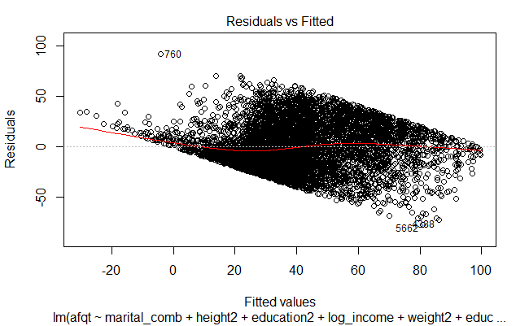

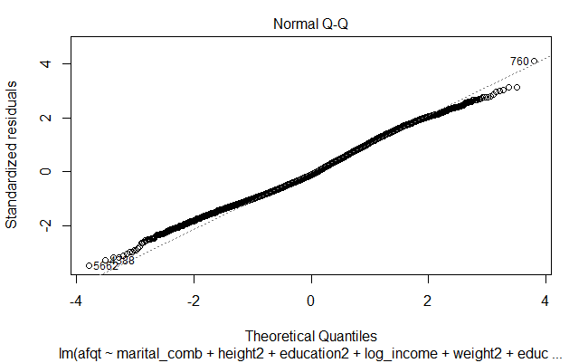

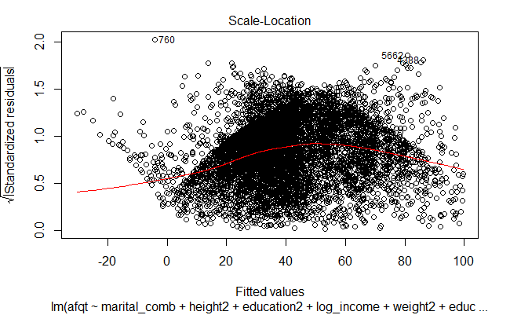

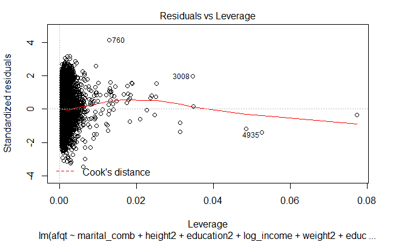

```r
plot(afqt_alt)
```

We could also attempt to convert the dependent variable (in a percentile metric) to a z-score.

```r
heights2 <- heights2 %>%
  mutate(
    afqt2 = ifelse(afqt == 0, .00001, ifelse(afqt == 100, 99.9999999, afqt)),
    afqt3 = ifelse(afqt %in% c(0, 100), NA, afqt),
    afqt_z = qnorm(afqt2/100),
    afqt_z3 = qnorm(afqt3/100)
  )
afqt_alt2 <- lm(afqt_z3 ~ marital_comb + height2 + education2 +
                 log_income + weight2 + education2_quad +
                 height2_quad + weight2_quad + log_income_quad,
               data = heights2)
summary(afqt_alt2)
```

```
Call:
lm(formula = afqt_z3 ~ marital_comb + height2 + education2 +
    log_income + weight2 + education2_quad + height2_quad + weight2_quad +
    log_income_quad, data = heights2)

Residuals:
    Min      1Q  Median      3Q     Max
-2.8910 -0.5105 -0.0064  0.4966  3.2479

Coefficients:
                       Estimate Std. Error t value Pr(>|t|)
(Intercept)          -1.119e+00  5.576e-02 -20.069  < 2e-16 ***
marital_combmarried   2.942e-01  2.782e-02  10.576  < 2e-16 ***
marital_combOther    -9.070e-02  4.242e-02  -2.138 0.032536 *
marital_combdivorced  1.701e-01  3.152e-02   5.395 7.09e-08 ***
height2               2.506e-02  2.769e-03   9.051  < 2e-16 ***
education2            1.933e-01  4.133e-03  46.769  < 2e-16 ***
log_income           -1.075e-02  2.897e-03  -3.710 0.000209 ***
weight2              -1.640e-03  2.800e-04  -5.859 4.88e-09 ***
education2_quad      -5.433e-04  8.880e-04  -0.612 0.540682
height2_quad         -1.316e-03  4.838e-04  -2.720 0.006545 **
weight2_quad          1.508e-05  2.906e-06   5.192 2.15e-07 ***
log_income_quad       7.100e-03  7.042e-04  10.083  < 2e-16 ***
---
Signif. codes:  0 â€˜***â€™ 0.001 â€˜**â€™ 0.01 â€˜*â€™ 0.05 â€˜.â€™ 0.1 â€˜ â€™ 1

Residual standard error: 0.7745 on 6588 degrees of freedom
  (406 observations deleted due to missingness)
Multiple R-squared:  0.4088,    Adjusted R-squared:  0.4078
F-statistic: 414.1 on 11 and 6588 DF,  p-value: < 2.2e-16
```

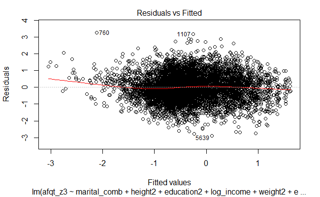

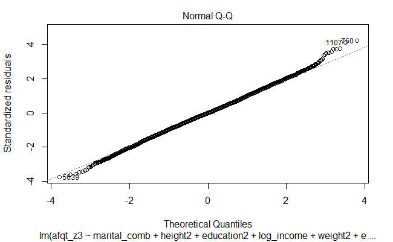

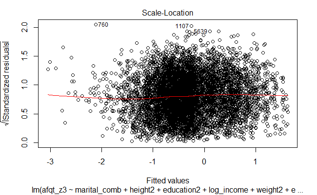

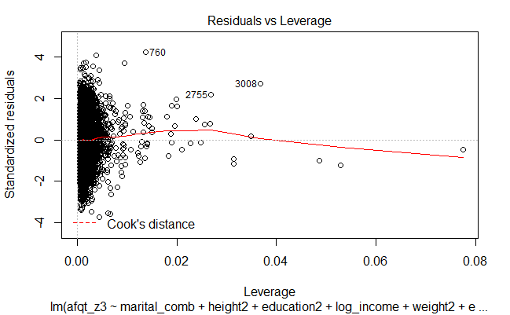

```r
plot(afqt_alt2)
```

## `glm` function

The `glm` function behaves much like the `lm` function. The only major difference in model logistics is that we will now need to specify a family argument. This family argument will depend on the type of model being fitted. We are going to perform a logistic regression, therefore this family will be binomial.

The data we will use is from Kaggle and is data from Titanic, more specifically the data has characteristics on the passengers and whether they survived the shipwreck or not. You can get a sense of the variables from this website: https://www.kaggle.com/c/titanic/data.

```r
titanic <- read_csv('Data/titanic.csv')
titanic
```

| PassengerId | Survived | Pclass | Name | Sex | Age | SibSp | Parch | Ticket | Fare | Cabin | Embarked |
| --- | --- | --- | --- | --- | --- | --- | --- | --- | --- | --- | --- |
| 1 | 0 | 3 | Braund, Mr. Owen Harris | male | 22.00 | 1 | 0 | A/5 21171 | 7.2500 | NA | S |
| 2 | 1 | 1 | Cumings, Mrs. John Bradley (Florence Briggs Thayer) | female | 38.00 | 1 | 0 | PC 17599 | 71.2833 | C85 | C |
| 3 | 1 | 3 | Heikkinen, Miss. Laina | female | 26.00 | 0 | 0 | STON/O2. 3101282 | 7.9250 | NA | S |
| 4 | 1 | 1 | Futrelle, Mrs. Jacques Heath (Lily May Peel) | female | 35.00 | 1 | 0 | 113803 | 53.1000 | C123 | S |
| 5 | 0 | 3 | Allen, Mr. William Henry | male | 35.00 | 0 | 0 | 373450 | 8.0500 | NA | S |
| 6 | 0 | 3 | Moran, Mr. James | male | NA | 0 | 0 | 330877 | 8.4583 | NA | Q |
| 7 | 0 | 1 | McCarthy, Mr. Timothy J | male | 54.00 | 0 | 0 | 17463 | 51.8625 | E46 | S |
| 8 | 0 | 3 | Palsson, Master. Gosta Leonard | male | 2.00 | 3 | 1 | 349909 | 21.0750 | NA | S |
| 9 | 1 | 3 | Johnson, Mrs. Oscar W (Elisabeth Vilhelmina Berg) | female | 27.00 | 0 | 2 | 347742 | 11.1333 | NA | S |
| 10 | 1 | 2 | Nasser, Mrs. Nicholas (Adele Achem) | female | 14.00 | 1 | 0 | 237736 | 30.0708 | NA | C |

[output cut: 881 more lines]

Suppose we were interested in fitting a model that predicted whether a passenger survived or not. Using `lm` is not appropriate as the dependent variable is not continuous, rather it is dichotomous. Using logistic regression is more appropriate here.

```r
surv_mod <- glm(Survived ~ factor(Pclass) + Fare + Sex + Age,
                data = titanic,
                family = binomial)
summary(surv_mod)
```

```
Call:
glm(formula = Survived ~ factor(Pclass) + Fare + Sex + Age, family = binomial,
    data = titanic)

Deviance Residuals:
    Min       1Q   Median       3Q      Max
-2.7393  -0.6788  -0.3956   0.6486   2.4639

Coefficients:
                  Estimate Std. Error z value Pr(>|z|)
(Intercept)      3.7225052  0.4645113   8.014 1.11e-15 ***
factor(Pclass)2 -1.2765903  0.3126370  -4.083 4.44e-05 ***
factor(Pclass)3 -2.5415762  0.3277677  -7.754 8.89e-15 ***
Fare             0.0005226  0.0022579   0.231    0.817
Sexmale         -2.5185052  0.2082017 -12.096  < 2e-16 ***
Age             -0.0367302  0.0077325  -4.750 2.03e-06 ***
---
Signif. codes:  0 â€˜***â€™ 0.001 â€˜**â€™ 0.01 â€˜*â€™ 0.05 â€˜.â€™ 0.1 â€˜ â€™ 1

(Dispersion parameter for binomial family taken to be 1)

    Null deviance: 964.52  on 713  degrees of freedom
Residual deviance: 647.23  on 708  degrees of freedom
  (177 observations deleted due to missingness)
AIC: 659.23

Number of Fisher Scoring iterations: 5
```

It is common to interpret these in terms of probability, we can do this with the following bit of code:

```r
prob_mod <- titanic %>%
  select(Survived, Pclass, Fare, Sex, Age) %>%
  na.omit() %>%
  mutate(
    probability = predict(surv_mod, type = 'response')
  )
prob_mod
```

| Survived | Pclass | Fare | Sex | Age | probability |
| --- | --- | --- | --- | --- | --- |
| 0 | 3 | 7.2500 | male | 22.00 | 0.10509514 |
| 1 | 1 | 71.2833 | female | 38.00 | 0.91404126 |
| 1 | 3 | 7.9250 | female | 26.00 | 0.55726903 |
| 1 | 1 | 53.1000 | female | 35.00 | 0.92162960 |
| 0 | 3 | 8.0500 | male | 35.00 | 0.06793029 |
| 0 | 1 | 51.8625 | male | 54.00 | 0.32031425 |
| 0 | 3 | 21.0750 | male | 2.00 | 0.19781236 |
| 1 | 3 | 11.1333 | female | 27.00 | 0.54860408 |
| 1 | 2 | 30.0708 | female | 14.00 | 0.87516354 |
| 1 | 3 | 16.7000 | female | 4.00 | 0.73937738 |

[output cut: 704 more lines]

We could now plot these probabilities to explore the effects.

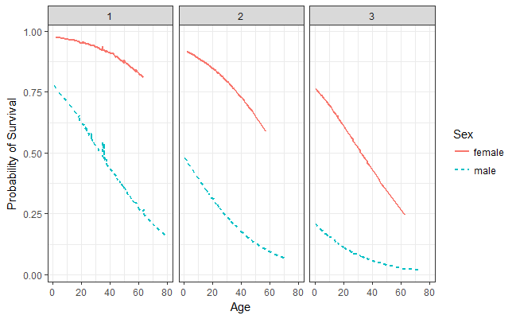

```r
ggplot(prob_mod, aes(Age, probability, color = Sex, linetype = Sex)) +
  geom_line(size = 1) +
  facet_grid(. ~ Pclass) +
  theme_bw() +
  xlab("Age") +
  ylab("Probability of Survival")
```